# Battle of the Bands: Coldplay vs Metallica

Abstract

Both Coldplay and Metallica are firm favourites for people’s favourite bands of all time, with both bands making music for over two decades. But, are these bands really comparable? Who should music producers choose to emulate if they wish to have a long and successful music career? This is what is analysed in this report.

## Introduction

Coldplay and Metallica are legendary bands that have managed to stay musically relevant for over two decades. These bands have distinctly different music styles but both seem to appeal to the masses. The bands are compared on the basis of popularity, so that music producers can get a clear idea of what style to emulate if they wish to increase their chances of having a long and successful music career.

## Popularity and Longevity

The figure below depicts Coldplay’s popularity by album that they’ve produced.

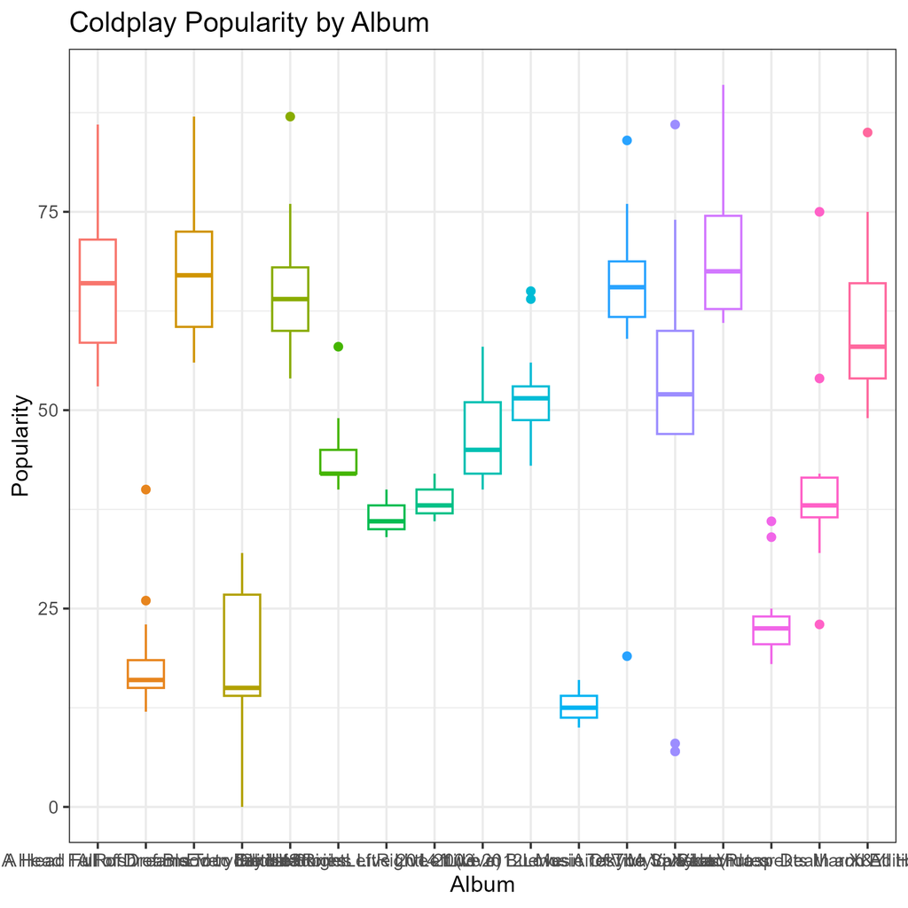

Similarly, the figure below summarises Metallica’s popularity by album.

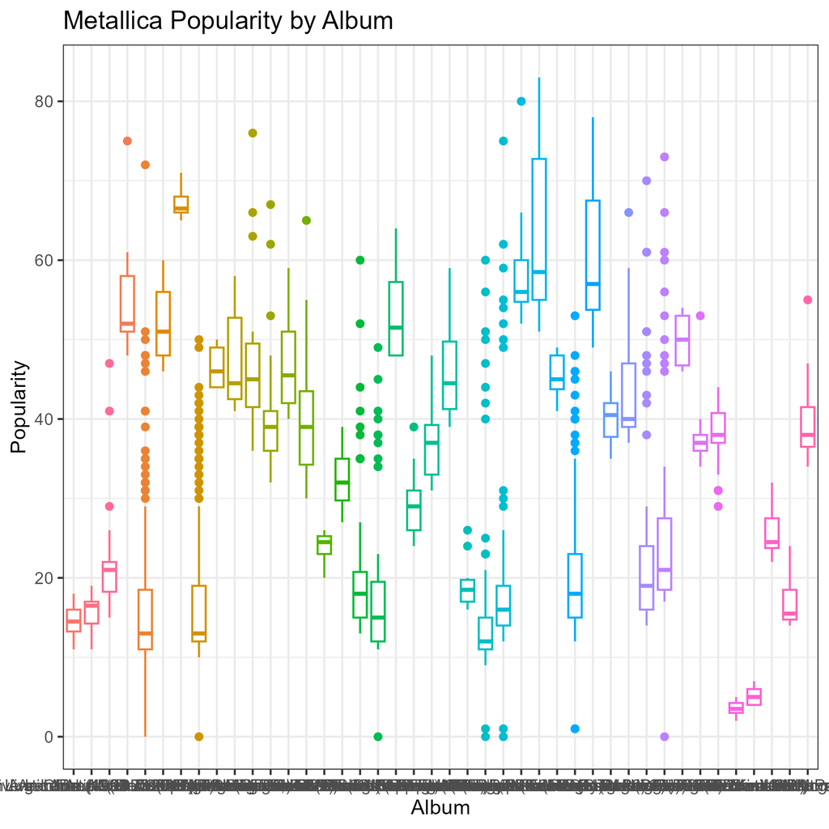

Upon inspection, it becomes clear that Metallica released many many more albums than Coldplay, with more individual songs being very popular (as indicated by the outliers). Metallica’s popularity tends to fall within either the first or third percentile of popularity, implying that the albums tend to hit or miss the mark with their audiences (creating a polarising effect on their popularity).

What is clear from both graphics is that not all albums are hits and neither band could remain consistently popular. Music producers and artists should thus not be discouraged if they release unpopular albums, and should keep producing new music.

From the preceding figures it is unclear whether one band is more popular than another. The figure below compares the bands’ average popularity over their existence.

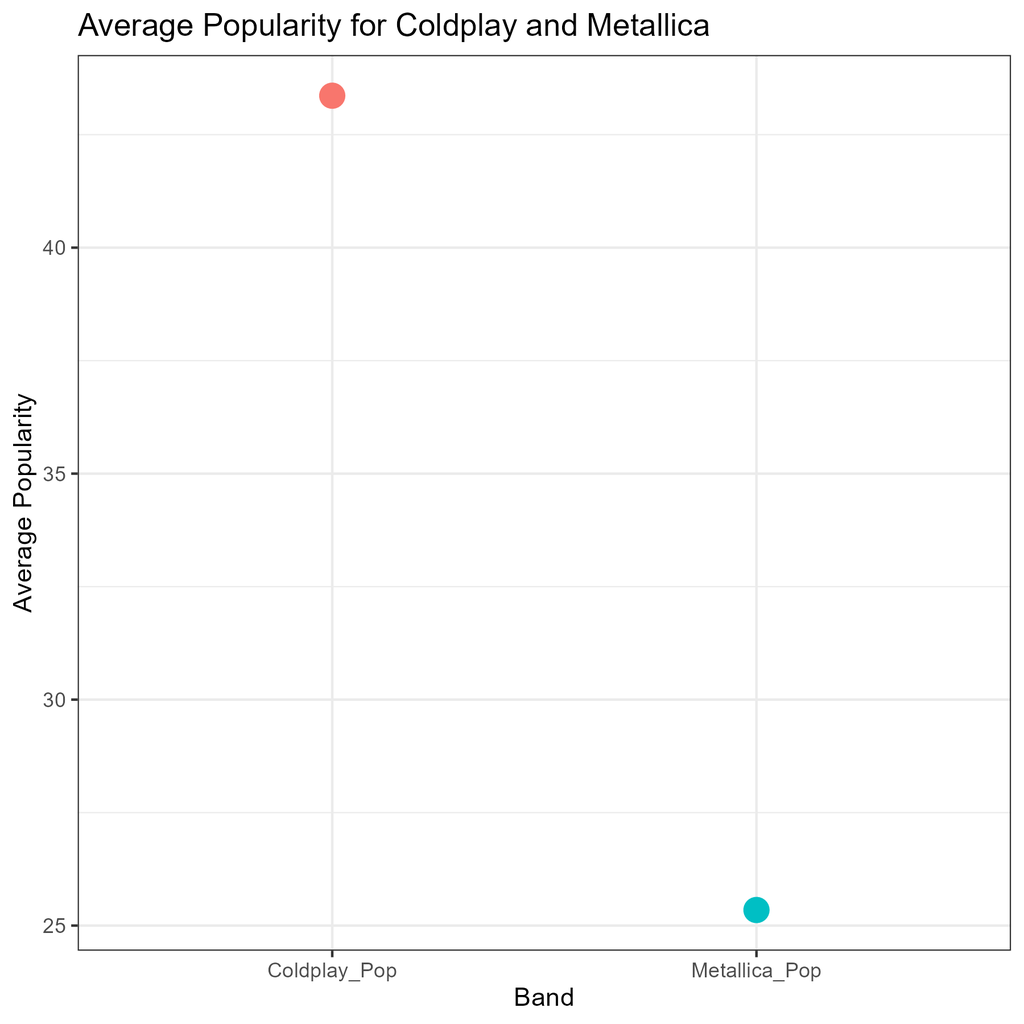

## Conclusion

Coldplay is far more popular than Metallica on average, where Metallica has a more polarising effect on their audience; sometimes they are just as popular as Colplay, and sometimes they are rather unpopular. Musicians and producers should thus try and emulate Coldplay if they want to increase their chances of having a long and successful musical career, and avoid being “one-hit-wonders.” Both bands seemed to have found success by continually releasing albums, even if preceding albums are unpopular.